# Pre-processing with phyloseq

Mar Schmidt

2026-04-13

```r
knitr::opts_chunk$set(echo = TRUE,
                      fig.align = "center",
                      # send any figure output to this folder
                      fig.path = "../../figures/Lecture/03_PreProcessing_Lecture/")
```

# Goals

The goal with this file is to pre-process any other contaminants and unexpected ASVs from our sample. We will need to:

1. Remove any contaminating ASVs that are **chloroplasts**.
2. Remove ASVs that are **mitochondria**.
3. Evaluate any ASVs from the **negative controls**. Then, remove negative controls.
4. Evaluate the mock community or **positive control** to learn the accuracy of sequencing.
5. Check for **reverse complements**.
6. Check the **sequencing depth** of samples. Remove samples that obviously have too few reads.
7. Add the metadata for class dataset (Note: Your data may already be in your `sample_data()`).
8. Write a `preprocessed_physeq` to be used in the next step of our workflow.

## Input

Here, we will start with the phyloseq object that we created in 02_AssignASVs.Rmd

1. **Raw phyloseq object**: We will need `data/02_AssignASVs/raw_phyloseq.RData`.
2. **Mock Amplicon Fasta**: Please copy over the `mock_amplicons.fasta` from `/workdir/in_class_data/` to your `data/03_PreProcessing` folder.

## Output

1. We will write out a complex R data object known as an **S4** object, which in this case is known as a phyloseq output. We will store this in `data/03_PreProcessing/preprocessed_phyloseq.RData`.

# Set up the Environment

## Set the seeds and threads

```r
# Set the seed for reproducibility
set.seed(238428)
```

## Timing of this script

Let’s record how long this file took to run on the class server, which we will record at the end of the script.

```r
# What time did we start running this script?
start_time <- Sys.time()
```

## Load packages

```r
# Load packages
pacman::p_load(devtools, phyloseq, Biostrings, tidyverse, dada2, patchwork,
               # Note to add ggpubr & rstatix!!
               ggpubr, rstatix, install = FALSE)
```

# Load Phyloseq Data

```r
# Load the data
load("data/Lecture/02_AssignASVs_Lecture/raw_physeq.RData")

# Look at the data
raw_physeq
```

```
## phyloseq-class experiment-level object
## otu_table()   OTU Table:         [ 3036 taxa and 95 samples ]
## sample_data() Sample Data:       [ 95 samples by 40 sample variables ]
## tax_table()   Taxonomy Table:    [ 3036 taxa by 9 taxonomic ranks ]
```

# Clean up the data

**Chloroplasts** and **mitochondria** need to be removed from 16S datasets because they contain their own 16S rRNA genes, which are evolutionarily derived from bacteria. These organelles can be unintentionally amplified during PCR, especially in samples from plants (chloroplasts) or animals (mitochondria), leading to misleading results by inflating microbial diversity.

This is explained by the endosymbiotic theory, which proposes that mitochondria and chloroplasts originated from free-living bacteria that were engulfed by ancestral eukaryotic cells. Over time, they became permanent, symbiotic organelles with their own genomes. Because of this bacterial ancestry, their 16S rRNA genes are similar to those targeted in bacterial 16S profiling, even though they are part of the host organism and not part of the microbial community being studied.

Removing these sequences ensures the analysis reflects true bacterial and archaeal diversity in the environment or host.

## 1. Remove Chloroplasts

```r
# Let's tak a quick look at the tax table
# View(tax_df) # Let's see where chloroplasts are and also mitochondria

# Make new physeq without chloroplasts
noChloros_physeq <-
  raw_physeq %>%
  # rm chloroplasts, which are Order
  subset_taxa(Order != "Chloroplast" | is.na(Order))

# How many taxa were chloroplasts?
num_chloro_ASVs <- ntaxa(raw_physeq) - ntaxa(noChloros_physeq)
num_chloro_ASVs
```

```
## [1] 248
```

```r
# Intuition chek
#noChloros_physeq %>%
#  tax_table() %>%
#  data.frame() %>%
#  View()
```

There were 248 ASVs that were chloroplasts.

## 2. Remove Mitochondria

```r
# remove mitochondria
noChlorosMitos_physeq <-
  noChloros_physeq %>%
  subset_taxa(Family != "Mitochondria" | is.na(Family))

# How many mitochondrial ASVs?
num_mito_ASVs <- ntaxa(noChloros_physeq) - ntaxa(noChlorosMitos_physeq)
num_mito_ASVs
```

```
## [1] 74
```

```r
# Let's take a quick look
noChlorosMitos_physeq
```

```
## phyloseq-class experiment-level object
## otu_table()   OTU Table:         [ 2714 taxa and 95 samples ]
## sample_data() Sample Data:       [ 95 samples by 40 sample variables ]
## tax_table()   Taxonomy Table:    [ 2714 taxa by 9 taxonomic ranks ]
```

There were 74 ASVs that were mitochondria in the data set.

INTERPRETATION #1: How many chloroplast and/or mitochondrial ASVs in your dataset? Does this seem reasonable?

```r
# How many total asvs were removed from chloros and mitos?
ntaxa(raw_physeq) - ntaxa(noChlorosMitos_physeq)
```

```
## [1] 322
```

```r
# proportion of asvs kept?
ntaxa(noChlorosMitos_physeq)/ntaxa(raw_physeq)
```

```
## [1] 0.8939394
```

# Evaulate and remove the control samples

Now, let’s take a look at the negative controls and then make a decision about whether or not to remove the ASVs that we found in our controls

1. Negative controls
2. ASVs found within the negative controls and their distribution in the samples.
3. Evaluate the mock community

## 3. Negative Controls

Including negative controls in your 16S sequencing workflow is a critical step that helps you identify potential contamination and confidently interpret your results—**especially if you’re working with low-biomass** samples like water, air, or host-associated (*e.g.,* skin, etc) surfaces.

Even in the cleanest labs, contamination can creep in at any point in the pipeline: from the DNA extraction kit, PCR reagents, plastic consumables, or even aerosols in the lab. These contaminants often include low-level bacterial DNA that can be amplified just as efficiently as your true sample DNA, leading to false signals in your data. Negative controls help you detect and remove these artifacts.

The main types of negative controls you should consider including in your 16S rRNA gene analyses include the following:

1. **DNA Extraction Blank (Extraction Negative Control):** This control is processed alongside your samples but without any actual biological material—you just use the extraction buffer or nuclease-free water. It goes through the entire DNA extraction process, just like your real samples. Each time you open a new kit another DNA extraction blank should be created! In our lab, we always record the lot number of our extraction kit and add it to the DNA metadata for that sample.
   - *Why it’s important:* This control helps you detect contamination introduced during the extraction step—often from kits (a phenomenon known as the kitome), tubes, pipette tips, or other surfaces.
2. **PCR No-Template Control (NTC):** For this control, you set up a PCR reaction using water instead of DNA as the template. Everything else—primers, polymerase, buffer—is the same as your actual PCR reactions.
   - *Why it’s important:* This checks for contaminants introduced during PCR setup, such as aerosolized DNA, primer dimer artifacts, or contamination from reagents like Taq or water.
   - *Note:* A NTC control should be included in your dataset from each step of PCR that your sample goes through. For example, **in the standard Illumina 2-step PCR library prep, two separate NTC controls should be included** for both the 1st PCR step where the 16S rRNA gene-specific primers are used with the Illumina adapter overhangs, and the 2nd PCR step where the indices and P5 and P7 are added to the end of the amplicons. Therefore, a blank sample that is carried all the way through barcoding, library prep, pooling, and sequencing. Treat it exactly like a real sample in your workflow. These control helps detect contamination introduced within and after PCR, such as cross-contamination during amplicon pooling, barcode cross-talk, or reagent contamination during library preparation.
3. **Field Control:** This type of control is a blank sample (*e.g.,* sterile water, buffer, or a clean swab) that is handled *exactly* like your real samples, but without exposure to the environment or biological material that is being studied. It goes through:
   - The same collection materials (e.g., bottles, filters, swabs).
   - The same handling (e.g., gloves, tools, transport containers).
   - And is stored or processed at the same time and under the same conditions as your actual field samples.
   - Extracted and prepared exactly as every other sample.
   - *What are examples of field controls?*
     - Examples:
       - *Water samples:* Pour sterile water into a sterile sampling bottle at the site (without exposing it to the lake/river), filter it as if it were a sample.
       - *Swab samples:* Open a sterile swab, wave it near the sampling area without touching anything, then store it with your other samples.
       - *Sediment or soil samples*: Open up the collection tube to the open air and use a clean scoop (with the same cleaning method as you would between actual samples) to transfer sterile material or nothing at all into your collection container.

Negative controls are not optional—they are essential for data quality, reproducibility, and trust in your results. By including extraction blanks, PCR no-template controls, and field controls, you’ll be equipped to identify contamination, assess its impact, and clean your data before making biological interpretations.

**So, here in this section we will use the negative control samples to:**

1. Make a phyloseq object that only has our negative controls.
2. Evaluate negative control ASVs in samples versus controls by visualizing potential ASV contaminants in negative controls using plots. Here, we will manually do it, but please be aware that there’s also the [decontam R Package](https://benjjneb.github.io/decontam/vignettes/decontam_intro.html) that does this, too!
3. Remove any ASVs in the negative controls.

### 3a. Evaluate Negative Control ASVs in Samples vs Controls

```r
# Make a phyloseq object with only the negative controls
neg_control_samples <- c("WaterControl", "022um-Control", "3um-Control", "DNA-Ext-Control")

# Create a phyloseq object with only negative controls
neg_control_physeq <-
  noChlorosMitos_physeq %>%
  subset_samples(., names %in% neg_control_samples) %>%
  # force remove ASVs with 0 counts
  prune_taxa(taxa_sums(.) > 0, .)

# Let's take a look
neg_control_physeq
```

```
## phyloseq-class experiment-level object
## otu_table()   OTU Table:         [ 31 taxa and 4 samples ]
## sample_data() Sample Data:       [ 4 samples by 40 sample variables ]
## tax_table()   Taxonomy Table:    [ 31 taxa by 9 taxonomic ranks ]
```

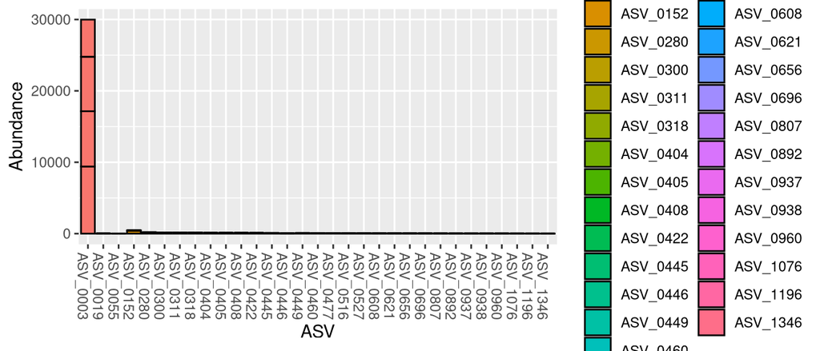

```r
# vector of negative control asvs
neg_control_ASVs <-
  neg_control_physeq %>%
  tax_table() %>%
  data.frame() %>%
  dplyr::select(ASV) %>%
  as.vector()

# Visualize raw abundance values of control ASVs
neg_control_physeq %>%
  plot_bar(., "ASV", fill = "ASV")
```

### 3b. Evaluate Negative Control ASVs in Samples vs Controls

```r
# What's the abundance of these neg control ASVs in real samples?
############# Check the control ASVs in the samples
# Make new phyloseq object with only the control ASVs and ALL samples
neg_controlASV_physeq <-
  noChlorosMitos_physeq %>%
  subset_taxa(., ASV %in% neg_control_ASVs$ASV)

# Inspect it
neg_controlASV_physeq
```

```
## phyloseq-class experiment-level object
## otu_table()   OTU Table:         [ 31 taxa and 95 samples ]
## sample_data() Sample Data:       [ 95 samples by 40 sample variables ]
## tax_table()   Taxonomy Table:    [ 31 taxa by 9 taxonomic ranks ]
```

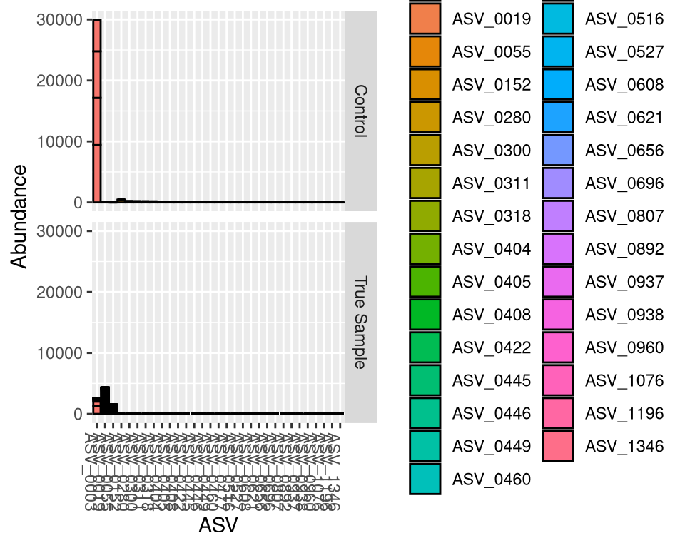

```r
# Plot Abundances of neg control ASVs in samples versus controls
neg_controlASV_physeq %>%
  plot_bar(., "ASV", fill = "ASV", facet_grid = Sample_or_Control~.)
```

Now, let’s take a look a bit more of a closer look at each ASV and evaluate the statistical significance.

```r
# Calculate the phylum relative abundance
# Note: The read depth MUST be normalized in some way: scale_reads
asv_negControls_df <-
  neg_controlASV_physeq %>%
  # agglomerate at the ASV level
  tax_glom(taxrank = "ASV") %>%
  # Melt to a long format
  psmelt()

# Check the taxonomy of each ASV
asv_negControls_df %>%
  dplyr::select(Kingdom:ASV) %>%
  distinct() # Each ASV's taxonomy will be in a single row
```

```
##     Kingdom         Phylum               Class               Order
## 1  Bacteria Pseudomonadota Gammaproteobacteria     Pseudomonadales
## 2  Bacteria Pseudomonadota Gammaproteobacteria     Pseudomonadales
## 3  Bacteria Actinomycetota      Actinobacteria     Mycobacteriales
## 4  Bacteria Pseudomonadota Alphaproteobacteria     Caulobacterales
## 5  Bacteria Pseudomonadota Alphaproteobacteria     Rhodobacterales
## 6  Bacteria Actinomycetota      Actinobacteria       Micrococcales
## 7  Bacteria Actinomycetota      Actinobacteria     Mycobacteriales
## 8  Bacteria Actinomycetota      Actinobacteria     Mycobacteriales
## 9  Bacteria Pseudomonadota Alphaproteobacteria     Caulobacterales
## 10 Bacteria Pseudomonadota Alphaproteobacteria     Rhodobacterales
## 11 Bacteria Pseudomonadota Gammaproteobacteria     Burkholderiales
## 12 Bacteria Actinomycetota      Actinobacteria       Micrococcales
## 13 Bacteria Pseudomonadota Alphaproteobacteria    Sphingomonadales
## 14 Bacteria Pseudomonadota Gammaproteobacteria     Pseudomonadales
```

[output cut: 49 more lines]

```r
dim(asv_negControls_df)
```

```
## [1] 2945   51
```

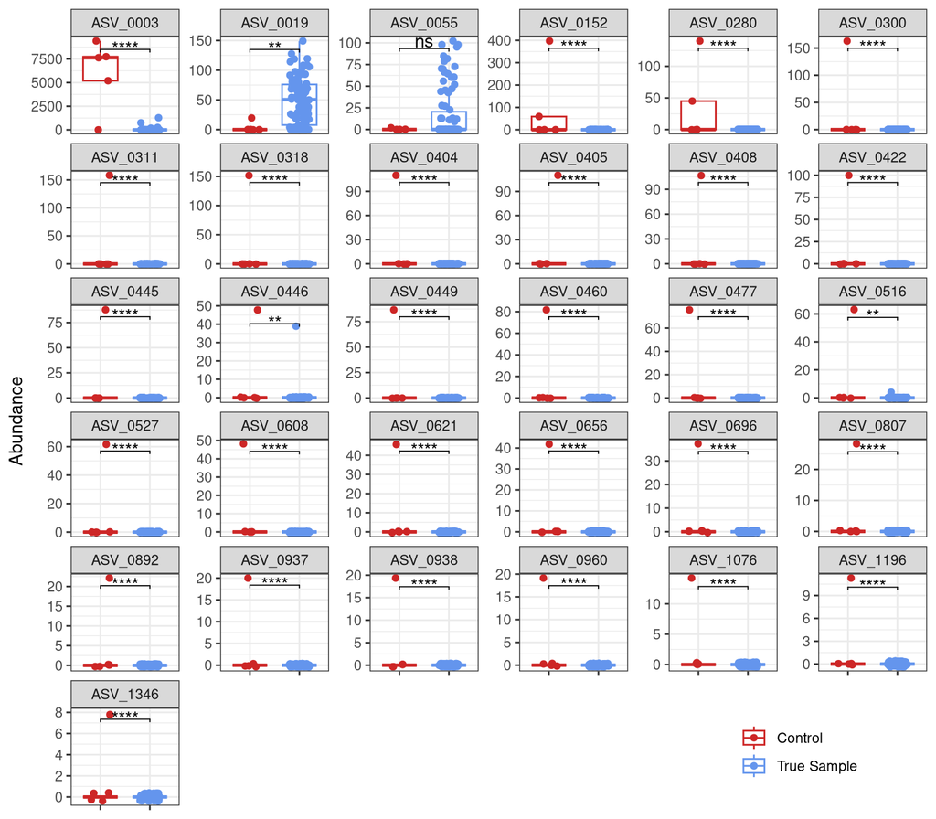

```r
# Statistically test!
negControl_ASV_statTest <-
  asv_negControls_df %>%
  group_by(ASV) %>%
  wilcox_test(Abundance ~ Sample_or_Control) %>%
  # Add the x and y positions for plotting
  adjust_pvalue(method = "fdr") %>%
  # Make the significance values be stars for plotting
  add_significance() %>%
  # Calculate where to place it on the facet grid plot
  add_xy_position(x = "Sample_or_Control", fun = "max", scales = "free") %>%
  # bring the pvalues a lil lower
  mutate(y.position = y.position * 0.82)

## Using ggpubr
ggboxplot(
  asv_negControls_df,
  x = "Sample_or_Control", y = "Abundance",
  color = "Sample_or_Control",
  facet.by = "ASV", scales = "free_y",add = "jitter") +
  stat_pvalue_manual(negControl_ASV_statTest) +
  scale_color_manual(values = c("firebrick3", "cornflowerblue")) +
  scale_fill_manual(values = c("firebrick3", "cornflowerblue")) +
  theme_bw() +
  theme(axis.text.x = element_blank(), axis.title.x = element_blank(),
        legend.title = element_blank(), legend.position = c(0.85, 0.07))
```

#### Check Taxonomy

```r
asv_negControls_df %>%
  dplyr::filter(OTU %in% neg_control_ASVs$ASV) %>%
  dplyr::select(Kingdom:ASV) %>%
  unique() %>%
  arrange(ASV)
```

```
##     Kingdom         Phylum               Class               Order
## 1  Bacteria Pseudomonadota Gammaproteobacteria     Pseudomonadales
## 2  Bacteria Actinomycetota      Actinobacteria       Micrococcales
## 3  Bacteria Pseudomonadota Gammaproteobacteria     Burkholderiales
## 4  Bacteria Pseudomonadota Gammaproteobacteria     Pseudomonadales
## 5  Bacteria Actinomycetota      Actinobacteria     Mycobacteriales
## 6  Bacteria Actinomycetota      Actinobacteria     Mycobacteriales
## 7  Bacteria Pseudomonadota Alphaproteobacteria     Caulobacterales
## 8  Bacteria Pseudomonadota Alphaproteobacteria     Rhodobacterales
## 9  Bacteria Actinomycetota      Actinobacteria     Mycobacteriales
## 10 Bacteria Pseudomonadota Alphaproteobacteria     Caulobacterales
## 11 Bacteria Pseudomonadota Alphaproteobacteria     Rhodobacterales
## 12 Bacteria Actinomycetota      Actinobacteria       Micrococcales
## 13 Bacteria Pseudomonadota Alphaproteobacteria    Sphingomonadales
## 14 Bacteria Pseudomonadota Gammaproteobacteria     Burkholderiales
```

[output cut: 49 more lines]

The taxonomy of the two ASVs in question are:

- `ASV_0019`: Genus is *Candidatus Aquiluna*, which is a common freshwater microbe that is often found in oligotrophic lakes, where it likely contributes to dissolved organic carbon utilization.
- `ASV_0055`: Family is *MWH-UniP1 aquatic group* and has been detected in low-nutrient (oligotrophic) aquatic environments and may be involved in organic carbon cycling. They are typically free-living planktonic microbes that survive by utilizing dissolved organic compounds.

Therefore, based on the taxonomy of the two ASVs in question, we should probably keep both of them!

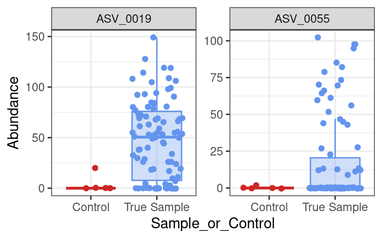

```r
# Let's zoom in only on these two that we care about!
asv_negControls_df %>%
  dplyr::filter(OTU %in% c("ASV_0019", "ASV_0055")) %>%
  ggplot(aes(x = Sample_or_Control, y = Abundance,
             color = Sample_or_Control, fill = Sample_or_Control)) +
  geom_boxplot(alpha =0.3, outlier.shape = NA) +
  geom_jitter() +
  facet_wrap(.~ASV, scales = "free") +
  scale_color_manual(values = c("firebrick3", "cornflowerblue")) +
  scale_fill_manual(values = c("firebrick3", "cornflowerblue")) +
  theme_bw() + theme(legend.position = "none")
```

### 3c. Remove any ASVs in the negative controls.

Now, let’s actually remove the ASVs that are more abundant in the negative controls compared to the samples.

```r
# Would only like to keep ASV_0019 and ASV_0055, everything else will be removed
controlASVs_toREMOVE <- dplyr::setdiff(neg_control_ASVs$ASV, c("ASV_0019", "ASV_0055"))
# double check
length(controlASVs_toREMOVE)
```

```
## [1] 29
```

```r
# Make new phyloseq object with negControl ASVs removed
noControlsChlorosMitos_physeq <-
  noChlorosMitos_physeq %>%
  # Actually remove the control ASVs
  subset_taxa(., !(ASV %in% controlASVs_toREMOVE)) %>%
  # Remove control samples
  subset_samples(., !(names %in% neg_control_samples))

# Inspect no controls object
noControlsChlorosMitos_physeq
```

```
## phyloseq-class experiment-level object
## otu_table()   OTU Table:         [ 2685 taxa and 91 samples ]
## sample_data() Sample Data:       [ 91 samples by 40 sample variables ]
## tax_table()   Taxonomy Table:    [ 2685 taxa by 9 taxonomic ranks ]
```

```r
# After filtering, how many ASVs were removed?
total_ASVs_rm <- ntaxa(raw_physeq) - ntaxa(noControlsChlorosMitos_physeq)
total_ASVs_rm
```

```
## [1] 351
```

INTERPRETATION #2: Did your dataset have any negative controls? If so, how many ASVs did you remove? Does that seem reasonable to you?

# 4. Positive Controls

### What is a positive control?

A **positive control** is a sample that should produce a known result, which allows researchers to verify accuracy, detect bias or contamination, and troubleshoot technical problems. In 16S sequencing, this usually means:

1. **A mock community**: A mixture of known microbial strains or DNA, with defined composition and relative abundances.
2. **A well-characterized natural sample**: For example, a fecal sample or environmental sample that’s been extensively profiled before and behaves consistently across experiments.

We will evaluate the accuracy of the sequencing run with the mock community, which we are using here as our “positive control”. To this you will need to access the `/workdir/in_class_data/mock_amplicons.fasta`, which is the file for the [ZymoBIOMICS Microbial Community DNA Standard](https://www.zymoresearch.com/collections/zymobiomics-microbial-community-standards/products/zymobiomics-microbial-community-dna-standard). We will:

1. Make a mock community phyloseq object
2. Load in the standard fasta sequences of the expected mock community using `/workdir/in_class_data/mock_amplicons.fasta`.
3. Test for differences between the sequenced mock communities and the known, expected sequences.

Before this next section, please make sure to copy over the `mock_amplicons.fasta` file from `/workdir/in_class_data/`

```r
# Make mock phyloseq object
mock_physeq <-
  noControlsChlorosMitos_physeq %>%
  subset_samples(., names == "MockZymoPos") %>%
  prune_taxa(taxa_sums(.) > 0, .)

# Inspect it
mock_physeq
```

```
## phyloseq-class experiment-level object
## otu_table()   OTU Table:         [ 8 taxa and 1 samples ]
## sample_data() Sample Data:       [ 1 samples by 40 sample variables ]
## tax_table()   Taxonomy Table:    [ 8 taxa by 9 taxonomic ranks ]
```

```r
tax_table(mock_physeq)
```

```
## Taxonomy Table:     [8 taxa by 9 taxonomic ranks]:
##          Kingdom    Phylum           Class                 Order
## ASV_0105 "Bacteria" "Pseudomonadota" "Gammaproteobacteria" "Enterobacterales"
## ASV_0121 "Bacteria" "Bacillota"      "Bacilli"             "Staphylococcales"
## ASV_0138 "Bacteria" "Pseudomonadota" "Gammaproteobacteria" "Enterobacterales"
## ASV_0139 "Bacteria" "Bacillota"      "Bacilli"             "Lactobacillales"
## ASV_0148 "Bacteria" "Bacillota"      "Bacilli"             "Bacillales"
## ASV_0181 "Bacteria" "Bacillota"      "Bacilli"             "Lactobacillales"
## ASV_0188 "Bacteria" "Bacillota"      "Bacilli"             "Lactobacillales"
## ASV_0229 "Bacteria" "Pseudomonadota" "Gammaproteobacteria" "Pseudomonadales"
##          Family               Genus                  Species ASV
## ASV_0105 "Enterobacteriaceae" "Salmonella"           NA      "ASV_0105"
## ASV_0121 "Staphylococcaceae"  "Staphylococcus"       NA      "ASV_0121"
## ASV_0138 "Enterobacteriaceae" "Escherichia-Shigella" NA      "ASV_0138"
## ASV_0139 "Listeriaceae"       "Listeria"             NA      "ASV_0139"
## ASV_0148 "Bacillaceae"        "Bacillus"             NA      "ASV_0148"
## ASV_0181 "Lactobacillaceae"   "Limosilactobacillus"  NA      "ASV_0181"
## ASV_0188 "Enterococcaceae"    "Enterococcus"         NA      "ASV_0188"
## ASV_0229 "Pseudomonadaceae"   "Pseudomonas"          NA      "ASV_0229"
##          ASVseqs
## ASV_0105 "AGGGTGCAAGCGTTAATCGGAATTACTGGGCGTAAAGCGCACGCAGGCGGTCTGTCAAGT…"
## ASV_0121 "AGGTGGCAAGCGTTATCCGGAATTATTGGGCGTAAAGCGCGCGTAGGCGGTTTTTTAAGT…"
## ASV_0138 "AGGGTGCAAGCGTTAATCGGAATTACTGGGCGTAAAGCGCACGCAGGCGGTTTGTTAAGT…"
## ASV_0139 "AGGTGGCAAGCGTTGTCCGGATTTATTGGGCGTAAAGCGCGCGCAGGCGGTCTTTTAAGT…"
## ASV_0148 "AGGTGGCAAGCGTTGTCCGGAATTATTGGGCGTAAAGGGCTCGCAGGCGGTTCCTTAAGT…"
## ASV_0181 "AGGTGGCAAGCGTTATCCGGATTTATTGGGCGTAAAGAGAGTGCAGGCGGTTTTCTAAGT…"
## ASV_0188 "AGGTGGCAAGCGTTGTCCGGATTTATTGGGCGTAAAGCGAGCGCAGGCGGTTTCTTAAGT…"
## ASV_0229 "AGGGTGCAAGCGTTAATCGGAATTACTGGGCGTAAAGCGCGCGTAGGTGGTTCAGCAAGT…"
```

```r
# write us a messages summarizing this
cat("DADA2 inferred", ntaxa(mock_physeq), "ASVs present in the mock community.")
```

```
## DADA2 inferred 8 ASVs present in the mock community.
```

```r
####### Load in the mock reference sequence from Zymo
mock_ref <- getSequences("data/Lecture/03_PreProcessing_Lecture/mock_amplicons.fasta")
names(mock_ref)
```

```
## [1] "Staphylococcus_aureus_16S_1"   "Salmonella_enterica_16S_1"
## [3] "Salmonella_enterica_16S_2"     "Pseudomonas_aeruginosa_16S_1"
## [5] "Listeria_monocytogenes_16S_1"  "Lactobacillus_fermentum_16S_1"
## [7] "Escherichia_coli_16S_1"        "Enterococcus_faecalis_16S_1"
## [9] "Bacillus_subtilis_16S_1"
```

```r
### Pull out seqs from Sequenced Mock community
mock_seqs <-
  mock_physeq %>%
  tax_table() %>%
  data.frame() %>%
  dplyr::select(ASV, ASVseqs)

# Inspect
head(mock_seqs)
```

```
##               ASV
## ASV_0105 ASV_0105
## ASV_0121 ASV_0121
## ASV_0138 ASV_0138
## ASV_0139 ASV_0139
## ASV_0148 ASV_0148
## ASV_0181 ASV_0181
##                                                                                                                                                                                                                                                        ASVseqs
## ASV_0105 AGGGTGCAAGCGTTAATCGGAATTACTGGGCGTAAAGCGCACGCAGGCGGTCTGTCAAGT…
## ASV_0121 AGGTGGCAAGCGTTATCCGGAATTATTGGGCGTAAAGCGCGCGTAGGCGGTTTTTTAAGT…
## ASV_0138 AGGGTGCAAGCGTTAATCGGAATTACTGGGCGTAAAGCGCACGCAGGCGGTTTGTTAAGT…
## ASV_0139 AGGTGGCAAGCGTTGTCCGGATTTATTGGGCGTAAAGCGCGCGCAGGCGGTCTTTTAAGT…
## ASV_0148 AGGTGGCAAGCGTTGTCCGGAATTATTGGGCGTAAAGGGCTCGCAGGCGGTTCCTTAAGT…
## ASV_0181 AGGTGGCAAGCGTTATCCGGATTTATTGGGCGTAAAGAGAGTGCAGGCGGTTTTCTAAGT…
```

```r
# Which ASVs match the reference?
matched_asvs <-
  mock_seqs %>%
  rowwise() %>%
  # check each ASV if they match, TRUE, if not = FALSE
  mutate(Match = any(grepl(ASVseqs, mock_ref))) %>%
  # Create a vector of names that matched
  pull(ASV)


# Evaluate which ones do NOT match??
# What's their abundances?
# This help provide error rate
cat(length(matched_asvs), "ASVs were exact matches to the expected reference sequence.")
```

```
## 8 ASVs were exact matches to the expected reference sequence.
```

```r
# How many sequences were in the mock?
mock_SeqDepth <-
  mock_physeq %>%
  otu_table() %>%
  data.frame() %>%
  colSums()

# Who is in the sequenced mock community?
mock_physeq %>%
  tax_table() %>%
  data.frame() %>%
  dplyr::select(Genus, Species)
```

```
##                         Genus Species
## ASV_0105           Salmonella    <NA>
## ASV_0121       Staphylococcus    <NA>
## ASV_0138 Escherichia-Shigella    <NA>
## ASV_0139             Listeria    <NA>
## ASV_0148             Bacillus    <NA>
## ASV_0181  Limosilactobacillus    <NA>
## ASV_0188         Enterococcus    <NA>
## ASV_0229          Pseudomonas    <NA>
```

```r
names(mock_ref)
```

```
## [1] "Staphylococcus_aureus_16S_1"   "Salmonella_enterica_16S_1"
## [3] "Salmonella_enterica_16S_2"     "Pseudomonas_aeruginosa_16S_1"
## [5] "Listeria_monocytogenes_16S_1"  "Lactobacillus_fermentum_16S_1"
## [7] "Escherichia_coli_16S_1"        "Enterococcus_faecalis_16S_1"
## [9] "Bacillus_subtilis_16S_1"
```

```r
# Curious: What are the mock counts in the actual samples
noControlsChlorosMitos_physeq %>%
  subset_taxa(., ASV %in% matched_asvs) %>%
  otu_table() %>%
  t()
```

```
## OTU Table:          [8 taxa and 91 samples]
##                      taxa are columns
##                   ASV_0105 ASV_0121 ASV_0138 ASV_0139 ASV_0148 ASV_0181
## 20210602-MA-ABB1F        0        0        0        0        0        0
## 20210602-MA-ABB1P        0        0        0        0        0        0
## 20210602-MA-ABB1W        0        0        0        0        0        0
## 20210602-MA-ABS1F        0        0        0        0        0        0
## 20210602-MA-ABS1P        0        0        0        0        0        0
## 20210602-MA-ABS1W        0        0        0        0        0        0
## 20210602-MA-CEB1F        0        0        0        0        0        0
## 20210602-MA-CEB1P        0        0        0        0        0        0
## 20210602-MA-CEB1W        0        0        0        0        0        0
## 20210602-MA-CES1F        0        0        0        0        0        0
## 20210602-MA-CES1P        0        0        0        0        0        0
## 20210602-MA-CES1W        0        0        0        0        0        0
## 20210602-MA-CWB1F        0        0        0        0        0        0
## 20210602-MA-CWB1P        0        0        0        0        0        0
## 20210602-MA-CWB1W        0        0        0        0        0        0
## 20210602-MA-CWS1F        0        0        0        0        0        0
## 20210602-MA-CWS1P        0        0        0        0        0        0
## 20210602-MA-CWS1W        0        0        0        0        0        0
## 20210602-MA-MBB1F        0        0        0        0        0        0
## 20210602-MA-MBB1P        0        0        0        0        0        0
## 20210602-MA-MBB1W        0        0        0        0        0        0
## 20210602-MA-MBS1F        0        0        0        0        0        0
## 20210602-MA-MBS1P        0        0        0        0        0        0
## 20210602-MA-MBS1W        0        0        0        0        0        0
## 20210602-MA-SCB1F        0        0        0        0        0        0
## 20210602-MA-SCB1P        0        0        0        0        0        0
## 20210602-MA-SCB1W        0        0        0        0        0        0
## 20210602-MA-SCS1F        0        0        0        0        0        0
## 20210602-MA-SCS1P        0        0        0        0        0        0
## 20210602-MA-SCS1W        0        0        0        0        0        0
## 20210615-MA-ABB2F        0        0        0        0        0        0
## 20210615-MA-ABB2P        0        0        0        0        0        0
## 20210615-MA-ABB2W        0        0        0        0        0        0
## 20210615-MA-ABS1F        0        0        0        0        0        0
## 20210615-MA-ABS1P        0        0        0        0        0        0
## 20210615-MA-ABS1W        0        0        0        0        0        0
## 20210615-MA-CEB1F        0        0        0        0        0        0
```

[output cut: 131 more lines]

```
## 20211005-MA-CWS1P        0        0
## 20211005-MA-CWS1W        0        0
## 20211005-MA-MBB1F        0        0
## 20211005-MA-MBB1P        0        0
## 20211005-MA-MBB1W        0        0
## 20211005-MA-MBS1F        0        0
## 20211005-MA-MBS1P        0        0
## 20211005-MA-MBS1W        0        0
## 20211005-MA-SCB1F        0        0
## 20211005-MA-SCB1P        0        0
## 20211005-MA-SCB1W        0        0
## 20211005-MA-SCS2F        0        0
## 20211005-MA-SCS2P        0        0
## 20211005-MA-SCS2W        0        0
## MockZymoPos            346      270
```

*What can we conclude about the mock community???*

INTERPRETATION #3: Did your dataset have a mock community? If so, what can you say about the accuracy of your sequencing run?

## Remove the mock community and it’s ASVs

```r
# Make a new phyloseq object without mock and its asvs
noControlsMock_ChlorosMitos_physeq <-
  noControlsChlorosMitos_physeq %>%
  # remove the mock community
  subset_samples(., names != "MockZymoPos") %>%
  # remove the ASVs from the mock
  subset_taxa(., !(ASV %in% matched_asvs))

# Inspect
noControlsMock_ChlorosMitos_physeq
```

```
## phyloseq-class experiment-level object
## otu_table()   OTU Table:         [ 2677 taxa and 90 samples ]
## sample_data() Sample Data:       [ 90 samples by 40 sample variables ]
## tax_table()   Taxonomy Table:    [ 2677 taxa by 9 taxonomic ranks ]
```

```r
# Intuition Check
num_ASVs_mock <- ntaxa(noControlsChlorosMitos_physeq) - ntaxa(noControlsMock_ChlorosMitos_physeq)

# Check
stopifnot(num_ASVs_mock == 8)
```

# 5. Reverse Complements

## What is a reverse complement?

Let’s take an example of the DNA sequence: 5’-ATGC-3’ → *Reverse*: CGTA → *Complement*: GCAT → *Reverse complement*: GCAT

## Why are reverse complements in my dataset?

During PCR amplification, sequencing, or bioinformatics processing, it’s possible that some sequences get read in the reverse orientation, are assigned to the wrong strand, or are present as both the forward and reverse complement versions in your dataset. This is especially common when using non-strand-specific sequencing protocols, the pipeline doesn’t enforce consistent orientation, or working with merged paired-end reads and haven’t filtered by orientation yet.

If you don’t check for reverse complements, you may accidentally treat identical sequences (just read in opposite directions) as different ASVs or OTUs. This can:

- Inflate your diversity estimates (counts two taxa when reality there is just one).
- Split read counts, reducing the apparent abundance of that ASV,
- Complicate taxonomic assignments, since tools may give different results depending on strand orientation.

## How to identify reverse complements?

- You can search your ASV or OTU table for reverse complement matches.
- If two sequences are reverse complements of each other, you can merge them and recalculate abundances.
- Tools like VSEARCH, USEARCH, or even custom scripts in R or Python can help identify reverse complements.
- Some pipelines (like DADA2) handle this automatically if you process all reads with the same orientation. This can be done in the `filterAndTrim()` step by using the `orient.fwd` parameter. But if you merge reads from multiple sources, it’s worth checking.

Reverse complements can show up in your dataset when identical sequences are read or processed in opposite orientations. If not accounted for, they can artificially inflate diversity and confuse your analyses. By searching for and collapsing reverse complements, you ensure that your 16S data is more accurate and biologically meaningful.

So, here we will manually search for reverse complements in the dataset since we forgot to use the `orient.fwd` parameter in our `filterAndTrim()` step. And, it’s always good to double check, even if we did!

```r
# Pull out Taxa Table
tax_table <-
  noControlsChlorosMitos_physeq %>%
  tax_table() %>%
  data.frame()

# Grab ASV Sequences and Names
asv_names <- tax_table$ASV
asv_seqs <- tax_table$ASVseqs

# Create empty comparison matrix
asv_rev_comp <- matrix(nrow=length(asv_seqs), ncol = length(asv_seqs))

# Fix the names in the rows and columns
rownames(asv_rev_comp) <- asv_names
colnames(asv_rev_comp) <- asv_names

# Convert sequences to Biostrings
asv_dna <- DNAStringSet(asv_seqs)

# Inspect
head(asv_dna)
```

```
## DNAStringSet object of length 6:
##     width seq
## [1]   245 GAGTGGCAAGCGTTATCCGGAATTATTGGGCGTA...TGACGCTCATGGACGAAAGCCAGGGGAGCGAAA
## [2]   245 GAGTGGCAAGCGTTATCCGGAATTATTGGGCGTA...TGACGCTCATGGACGAAAGCCAGGGGAGCGAAA
## [3]   245 GGGGGCGAGCGTTGTCCGGATTTATTGGGCGTAA...CGACGCTGAGGAGCGAAAGCTAGGGGAGCAAAC
## [4]   245 GGGGGCGAGCGTTGTCCGGATTTATTGGGCGTAA...CGACGCTGAGGAGCGAAAGCTAGGGGAGCAAAC
## [5]   245 AAGGTCCAAGCGTTAATCGGAATTACTGGGCGTA...TGACACTGAGGTGCGAAAGCGTGGGTAGCGAAC
## [6]   245 GAGTGGCAAGCGTTATCCGGAATTATTGGGCGTA...TGACGCTCATGGACGAAAGCCAGGGGAGCGAAA
```

```r
# Construct reverse complement
asv_rev_dna <- reverseComplement(asv_dna)

# Now loop through every asv sequence to check
for(i in 1:length(asv_seqs)){ # For each asv sequence...
  match_vec <- asv_dna[i] == asv_rev_dna # Compare it to the reverse complement of every other sequence...
  asv_rev_comp[,i] <- match_vec # Write that logical vector as a new column
}

# Find how many TRUEs (matches) we have, divide by 2 because each pair occurs twice
cat("For", sum(asv_rev_comp) / 2,"ASVs, the reverse complement will need to be removed")
```

```
## For 0 ASVs, the reverse complement will need to be removed
```

INTERPRETATION #4: Do you have any reverse complements in your dataset?

# 6. Sequencing Depth

Sequencing depth (also known as the library size of a sample) is the number of reads per sample. It affects how well we can detect and compare microbes between samples. Normalizing for sequencing depth is essential for fair and accurate analysis in microbial studies.

At first glance, you might expect that different types of samples—like soil, water, or gut—would naturally have different sequencing depths. After all, they have different microbial loads, right? But in practice, sequencing depth is more about the lab and sequencing process than the biology of the sample itself.

Remember that:

- **Sequencing depth reflects how many reads are returned—not microbial biomass**
  - Sequencing depth is the number of reads assigned to a sample after sequencing—not the number of microbes present.
  - Two samples (*e.g.,* one from soil, one from water) can end up with the same number of reads, even if one has far more microbial biomass than the other.
  - This is because library preparation, PCR efficiency, and pooling determine how many reads each sample gets—not the sample’s biology.
- **Sequencing depth is ifluenced by gechnical factors**
  - *DNA extraction efficiency*: Some samples (*e.g.,* soil) are harder to extract DNA from, but if extraction is successful, the sequencing depth can still be high.
  - *PCR amplification*: Some samples amplify better than others due to inhibitors or DNA quality, but PCR bias can equalize or distort actual abundance.
  - *Pooling strategy*: When libraries are pooled before sequencing, each sample is assigned a roughly equal proportion of reads, regardless of the sample type.
  - *Demultiplexing* errors or sequencing bias can also affect how many reads are recovered per sample.
- **Sequencing depth is not a measure of microbial diversity or complexity**
  - A complex community (*e.g.,* soil) and a simple one (*e.g.,* a mock community) can both be sequenced to the same depth.
  - You may need higher sequencing depth to capture rare taxa in complex communities, but the sequencer won’t automatically give you that—it just sequences what’s there in the library.

## Why does sequencing depth matter?

- Higher depth = better detection of rare microbes.
- Too low depth may miss important community members and give unreliable diversity estimates.
- Uneven depth across samples can bias comparisons between microbial communities.

## How to deal with unequal sequencing depth?

We often normalize for sequencing depth before comparing samples using methods like:

- *Rarefaction*: Subsampling many times (typically 1,000 times) to an even depth.
- *Scaling*: Transform sample counts by multiplying by the ASV count by the minimum library size in the dataset.
- *Proportional normalization*: Converting to relative abundance (all ASV values within a sample add up to 1).
- *Statistical modeling*: DESeq2, which accounts for depth.

Let’s take a look!

```r
# The current data object
noControlsMock_ChlorosMitos_physeq
```

```
## phyloseq-class experiment-level object
## otu_table()   OTU Table:         [ 2677 taxa and 90 samples ]
## sample_data() Sample Data:       [ 90 samples by 40 sample variables ]
## tax_table()   Taxonomy Table:    [ 2677 taxa by 9 taxonomic ranks ]
```

```r
# Make a metadata_df for joining
metadata_df <-
  noControlsMock_ChlorosMitos_physeq %>%
  sample_data() %>%
  data.frame()

# What is the library size/sequencing depth for each sample?
seqSums_df <-
  noControlsMock_ChlorosMitos_physeq %>%
  otu_table() %>%
  # Sum each sample column
  colSums() %>%
  data.frame() %>%
  rownames_to_column(var = "names") %>%
  left_join(., metadata_df, by = "names")

# Rename second column
colnames(seqSums_df)[2] <- "TotalSeqs"

# check
dim(seqSums_df)
```

```
## [1] 90 41
```

```r
head(seqSums_df)
```

```
##               names TotalSeqs year day project     station depth replicate
## 1 20210602-MA-ABB1F      4079 2021  02      MA Aransas Bay   2.5         1
## 2 20210602-MA-ABB1P      3087 2021  02      MA Aransas Bay   2.5         1
## 3 20210602-MA-ABB1W      5749 2021  02      MA Aransas Bay   2.5         1
## 4 20210602-MA-ABS1F      3843 2021  02      MA Aransas Bay   0.0         1
## 5 20210602-MA-ABS1P      3767 2021  02      MA Aransas Bay   0.0         1
## 6 20210602-MA-ABS1W      4779 2021  02      MA Aransas Bay   0.0         1
##   fraction   date month vol_filtered_mL DNA_conc1a_nguL total_uL_DNA tot_ng
## 1     Free 6/2/21  June             360           25.90        44.61   1207
## 2 Particle 6/2/21  June             360            2.91        34.00    105
## 3    Whole 6/2/21  June             360           65.30        43.36   2962
## 4     Free 6/2/21  June             300           39.70        44.94   1864
## 5 Particle 6/2/21  June             300           10.40        42.54    463
## 6    Whole 6/2/21  June             300           47.40        45.11   2233
##   DNA_conc1b_nguL  DNA_conc2_nguL tot_filtration_time collection_time
```

[output cut: 34 more lines]

```r
# Show the depth of samples
seqSums_df %>%
  dplyr::select(names, TotalSeqs) %>%
  arrange(TotalSeqs) %>%
  head()
```

```
##               names TotalSeqs
## 1 20210615-MA-SCB2F         0
## 2 20210615-MA-ABB2F      1844
## 3 20210602-MA-SCB1P      2107
## 4 20210602-MA-CWS1P      2270
## 5 20210602-MA-MBB1P      2667
## 6 20211005-MA-CWS1P      2671
```

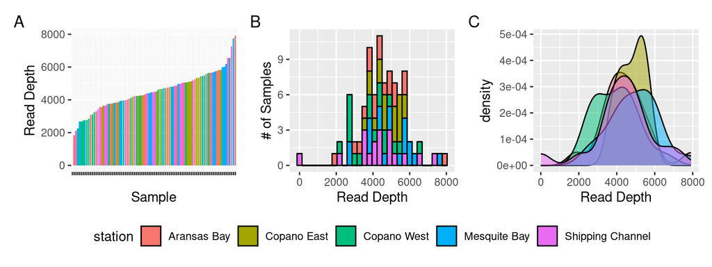

```r
# plot it as a bar plot
numSeq_bar_plot <-
  seqSums_df %>%
  ggplot(aes(x=reorder(names, TotalSeqs), y = TotalSeqs,
             fill = station)) +
  geom_bar(stat = "identity") +
  theme(axis.text.x = element_blank()) +
  labs(y = "Read Depth", x = "Sample") +
  theme(legend.position = "none")

# histogram
numSeq_hist_plot <-
  seqSums_df %>%
  ggplot(aes(x= TotalSeqs, fill = station)) +
  geom_histogram(color = "black") +
  labs(y = "# of Samples", x = "Read Depth") +
  theme(legend.position = "bottom")

# Density plot
numSeq_density_plot <-
  seqSums_df %>%
  ggplot(aes(TotalSeqs, fill = station)) +
  geom_density(alpha = 0.5) +
  labs(x = "Read Depth") +
  theme(legend.position = "none")

# Put it all together
numSeq_bar_plot + numSeq_hist_plot + numSeq_density_plot +
  plot_annotation(tag_levels = "A")
```

INTERPRETATION #5: What can you conclude about your sequencing depths? What are your sample distributions? Do you have “enough” reads? Are there any samples that should be removed at this step?

## Remove samples with few reads

If you find any samples that should obviously be removed at this step, you can follow the code below for your samples. However, if your samples have some but not many reads—like 1000 counts-it is worthwhile to keep those samples in your dataset and remove them later, especially if they are very important!

You can watch this video by [Dr. Pat Schloss](https://riffomonas.org/code_club/2022-04-07-sampling-depth), which talks about how to find the best sampling depth for rarefaction to give you some idea.

```r
# What's the min seq depth?
min(sample_sums(noControlsMock_ChlorosMitos_physeq))
```

```
## [1] 0
```

```r
# Remove 20210615-MA-SCB2F
preprocessed_physeq <-
  noControlsMock_ChlorosMitos_physeq %>%
  subset_samples(., names != "20210615-MA-SCB2F")

#What's the new min seq depth?
min(sample_sums(preprocessed_physeq))
```

```
## [1] 1844
```

```r
# Final check of the sequencing depth for now
# Here, we could remove more samples if we needed to
seqSums_df %>%
  dplyr::select(names, TotalSeqs) %>%
  arrange(TotalSeqs)
```

```
##                names TotalSeqs
## 1  20210615-MA-SCB2F         0
## 2  20210615-MA-ABB2F      1844
## 3  20210602-MA-SCB1P      2107
## 4  20210602-MA-CWS1P      2270
## 5  20210602-MA-MBB1P      2667
## 6  20211005-MA-CWS1P      2671
## 7  20211005-MA-CWB1W      2749
## 8  20210602-MA-MBS1P      2766
## 9  20211005-MA-CWS1W      2770
## 10 20210602-MA-CWB1F      2853
## 11 20210602-MA-ABB1P      3087
## 12 20211005-MA-CWB1P      3105
## 13 20211005-MA-CWB1F      3253
## 14 20210615-MA-ABB2P      3312
```

[output cut: 76 more lines]

# 7. Add some metadata

*Likely, you do not need to do this step as you already have the data in your metadata! If so, you can skip this step. That is because this step is unique to the in class dataset that we are working with and will be used for visualization purposes for statistical testing later.*

Here, we will make a continuous value into a discrete value for plotting purposes later. We will add:

1. A discrete column called `salinity_group` that is made from the continuous data as indicated below.
2. The Sequencing Depth of each sample

We will add the salinity group based on the follow values. We will also make sure the metadata is in the correct order for analyses later.

| Salinity Group | Range (PSU) | Count |
| --- | --- | --- |
| Very Low | 0–7 | 5 |
| Low | >7–13 | 5 |
| Mid | >13–20 | 11 |
| High | >20 | 8 |

```r
# Let's add a metadata column to the file for this dataset before moving on.
# We will create a discrete, categorical variable called "salinity_group" out of the continuous form of the data.
#
metadata_df <-
  preprocessed_physeq %>%
  sample_data() %>%
  data.frame() %>%
  mutate(depth_cat = ifelse(depth == 0.0, "surface", "bottom"),
         # Create a new column for salinity group
         salinity_group = factor(
           cut(salinity_psu,
               breaks = c(-Inf, 7, 13, 20, Inf),
               labels = c("Very Low", "Low", "Mid", "High"),
               right = TRUE),
           # Make sure the factor order is correct
           levels = c("Very Low", "Low", "Mid", "High"), ordered = TRUE),
         # Fix the factor orders for date, station, and depth category
         date = factor(date, levels = c("6/2/21", "6/15/21", "10/5/21"), ordered = TRUE),
         depth_cat = factor(depth_cat, levels = c("surface", "bottom"), ordered = TRUE),
         station = factor(station, levels = c("Copano West", "Copano East","Mesquite Bay",
                                              "Aransas Bay","Shipping Channel"),
                          ordered = TRUE))

### Let's add the sequencing count data, so that doesn't get lost!
# What are the sample size distributions?
num_seqs_df <-
  preprocessed_physeq %>%
  sample_sums() %>%
  data.frame() %>%
  rownames_to_column(var = "names")

# Fix the column names
colnames(num_seqs_df)[2] <- "Sequencing_Depth"

# Now merge it all
metadata_df2 <-
  metadata_df %>%
  left_join(num_seqs_df, by = "names")

## Check they match
stopifnot(metadata_df$names == metadata_df2$names)

# Rename the rows
rownames(metadata_df2) <- metadata_df2$names

# Reassign to the phyloseq object, rewriting the old metadata
sample_data(preprocessed_physeq) <- metadata_df2

# Double check
colnames(data.frame(sample_data(preprocessed_physeq)))
```

```
##  [1] "names"               "year"                "day"
##  [4] "project"             "station"             "depth"
##  [7] "replicate"           "fraction"            "date"
## [10] "month"               "vol_filtered_mL"     "DNA_conc1a_nguL"
## [13] "total_uL_DNA"        "tot_ng"              "DNA_conc1b_nguL"
## [16] "DNA_conc2_nguL"      "tot_filtration_time" "collection_time"
## [19] "process_time"        "sitting_time"        "julian_day"
## [22] "total_filter"        "used_filter"         "filter_left"
## [25] "X10min_65"           "dna_kit"             "vol_DNAused_16S"
## [28] "vol_qPCR"            "labnote_page"        "Sample_or_Control"
## [31] "time"                "water_tempC"         "SpCond_mS"
## [34] "salinity_psu"        "pH"                  "turbidity_NTU"
## [37] "chlorophyll_ugL"     "percent_DO"          "DO_mgL"
## [40] "notes"               "depth_cat"           "salinity_group"
## [43] "Sequencing_Depth"
```

```r
# Intuition check
head(num_seqs_df)
```

```
##               names Sequencing_Depth
## 1 20210602-MA-ABB1F             4079
## 2 20210602-MA-ABB1P             3087
## 3 20210602-MA-ABB1W             5749
## 4 20210602-MA-ABS1F             3843
## 5 20210602-MA-ABS1P             3767
## 6 20210602-MA-ABS1W             4779
```

# 8. Write out the data

Finally, let’s save our phyloseq object, which we will use for the next step!

```r
# Please be sure to use the correct path to the appropriate directory in your file system
save(preprocessed_physeq, file = "data/Lecture/03_PreProcessing_Lecture/preprocessed_phyloseq.RData")
```

# Final info for Reproducibility

## Check Render Time

```r
# Take the time now that we are at the end of the script
end_time <- Sys.time()
end_time
```

```
## [1] "2026-04-13 17:36:21 EDT"
```

```r
# Echo the elapsed time
elapsed_time <- round((end_time - start_time), 3)
elapsed_time
```

```
## Time difference of 23.558 secs
```